# Video All-Platform Consumption Trends - ATUS, Nielsen & Hakuhodo

NBCU Corporate Digital Measurement Strategy

April 13, 2018

## EXECUTIVE SUMMARY

As traditional TV viewing declines, the natural questions to ask are…where are viewers going and what are they doing? Unfortunately, these very simple questions have many answers depending on who you ask. Of critical concern to long-form video programmers is whether or not there’s still an opportunity to capture viewers’ attention. The business question is presented in this way…“even if we perfectly execute video content, if there’s no opportunity…then what difference does it make?”.

The data and information we’ve explored in this analysis infers that the bulk of the decline in live TV video usage is transferring over to video consumption on other platforms - as opposed to other non-video forms of online activity. The data further shows, that more time allocated to online usage does not detract from cross-platform video consumption.

Our analysis utilizes secondary research from the U.S Bureau of Labor Statistic’s American Time Usage Survey, Pivotal Research estimated based on Nielsen data. For comparative analysis, Tokyo based survey research conducted by the Hakuhodo research firm, was also included.

Fundamentally, video content makers are still competing among themselves, and not with application makers for engagement. We’re also able to see, that viewing video programming on a TV screen is alive and well. Further, Netflix reports that despite new users signing up on phones and laptops, 70% of viewing occurs on a connected TV[^1].

It’s also important to know that sometimes OTT providers can get it wrong. An example is Hulu Japan, which flopped because it had content that wasn’t relevant to its market, at very high price point ($19.25/per month) [^2]. In 2014, Hulu Japan was sold to Nippon TV, which was able to expand its catalog with local content, and lower the price to (900 Yen/$8.50)[^3].

Today, in the US market, it’s cheaper to channel surf on OTT SVOD than cable TV - representing an opportunity for some, and new challenges for others. Technology itself isn’t the driver, it appears to be content and price. Technology has been a facilitator of competition, but itself is not the draw.

## METHODOLOGY & DATA SOURCES: ATUS, Nielsen & Hakuhodo

The American Time Usage Survey (ATUS) is a very high-level report, that doesn’t distinguish between video viewing platforms. ATUS’s TV usage survey question covers what is essentially viewing long-form “TV” content on any platform. The same principle applies to the computer usage question, it applies to mobile and desktop, excluding gaming activity. ATUS survey data gives us a trended look from 2003-2016. There are a total of three charts in our analysis from this data source.

Pivotal Research, using Nielsen data created a custom total annual hours viewing metrics for cross-platform TV viewing (including online and OTT), as well as for Live TV only. The date range for this study is from 2008-2016. There are a total two charts in our analysis from this data set.

Finally, for the purposes of a comparative analysis, we’ll look at survey data from the Hakuhodo research firm. Hakuhodo’s survey also asks about TV viewing, but it is confined to live TV.

Each of these research methods have strengths and weaknesses. The survey data from Bureau of Labor and Statistics is crude and imprecise, but it is the same over time and truly is A/B in scope. In other words, the survey data’s imprecision is both a strength and weakness.

The Pivotal Research projection is a custom calculation that only spans eight years. However, it does offer aggregate counts for very specific platforms using Nielsen data. It can also be further segmented, in ways that it was not for this study. Also it is unclear how much of the aggregated sum is driven by normal population growth.

## DATA EXPLORATION & ANALYSIS

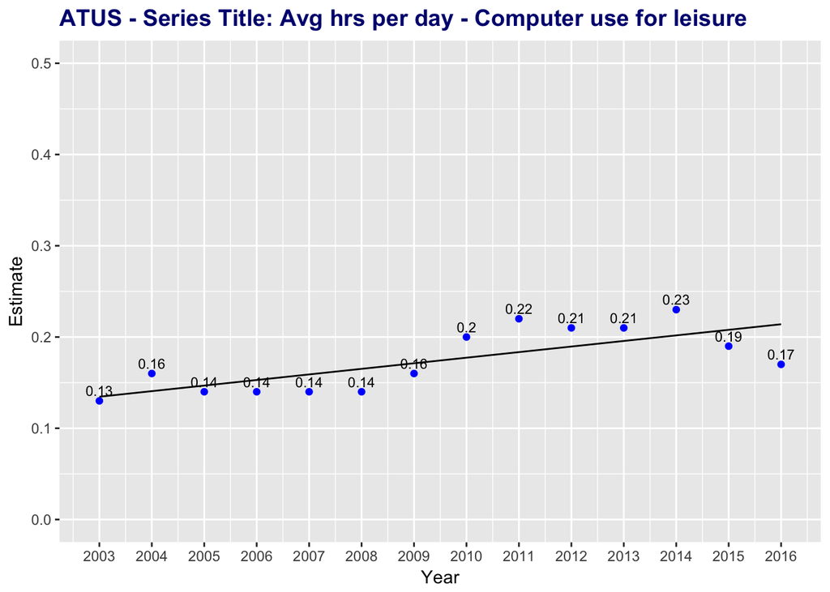

ATUS Data Source:[^4]

```
##    Min. 1st Qu.  Median    Mean 3rd Qu.    Max.
##  0.1300  0.1400  0.1650  0.1743  0.2075  0.2300
```

```
##
## Call:
## lm(formula = Estimate ~ Year, data = ATUS_Compdf)
##
## Residuals:
##       Min        1Q    Median        3Q       Max
## -0.044000 -0.016643 -0.005681  0.020159  0.036549
##
## Coefficients:
##              Estimate Std. Error t value Pr(>|t|)
## (Intercept) -12.10354    3.27476  -3.696  0.00306 **
## Year          0.00611    0.00163   3.749  0.00277 **
## ---
## Signif. codes:  0 '***' 0.001 '**' 0.01 '*' 0.05 '.' 0.1 ' ' 1
##
## Residual standard error: 0.02458 on 12 degrees of freedom
## Multiple R-squared:  0.5395, Adjusted R-squared:  0.5011
## F-statistic: 14.06 on 1 and 12 DF,  p-value: 0.002775
```

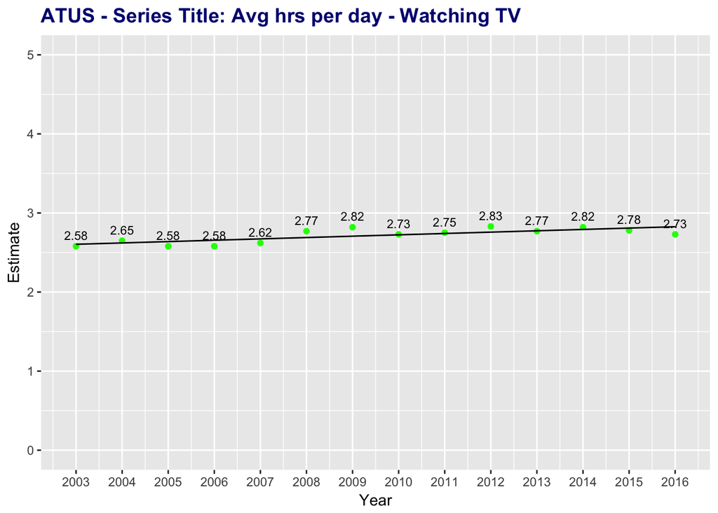

ATUS Data Source:[^5]

According to the ATUS survey, respondents report watching TV on any platform, all days of the week, for 2.72 hours per day.

The regression shows that viewing on any platform has been growing at 1 minute per year from 2003-2016 on average, and is statistically significant at 99% confidence interval. See output below:

```
##    Min. 1st Qu.  Median    Mean 3rd Qu.    Max.
##   2.580   2.628   2.740   2.715   2.778   2.830
```

```
##
## Call:
## lm(formula = Estimate ~ Year, data = ATUS_TV_Alldf)
##
## Residuals:
##       Min        1Q    Median        3Q       Max
## -0.096000 -0.046462  0.000846  0.028731  0.113538
##
## Coefficients:
##               Estimate Std. Error t value Pr(>|t|)
## (Intercept) -31.601077   8.496594  -3.719  0.00293 **
## Year          0.017077   0.004228   4.039  0.00164 **
## ---
## Signif. codes:  0 '***' 0.001 '**' 0.01 '*' 0.05 '.' 0.1 ' ' 1
##
## Residual standard error: 0.06377 on 12 degrees of freedom
## Multiple R-squared:  0.5762, Adjusted R-squared:  0.5408
## F-statistic: 16.31 on 1 and 12 DF,  p-value: 0.001643
```

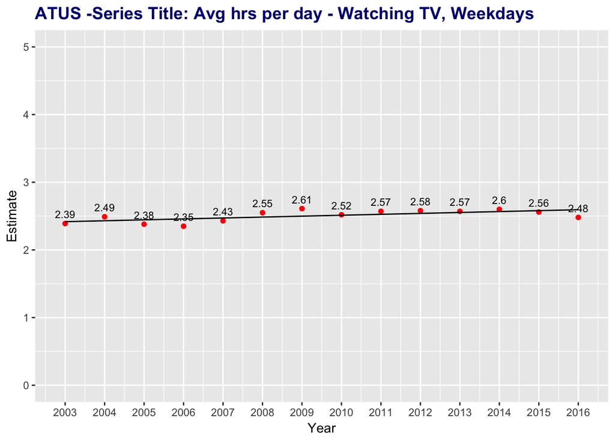

ATUS Data Source:[^6]

According to the ATUS survey, respondents report watching TV on any platform, on weekdays, for 2.51 hours per day.

The regression shows that viewing on any platform has been growing at 49 seconds per year from 2003-2016 on average, and is statistically significant at 95% confidence interval. See output below:

```
##    Min. 1st Qu.  Median    Mean 3rd Qu.    Max.
##   2.350   2.443   2.535   2.506   2.570   2.610
```

```
##
## Call:
## lm(formula = Estimate ~ Year, data = ATUS_TV_wkdaydf)
##
## Residuals:
##      Min       1Q   Median       3Q      Max
## -0.11400 -0.03818  0.01212  0.04302  0.11108
##
## Coefficients:
##              Estimate Std. Error t value Pr(>|t|)
## (Intercept) -24.78815    9.16388  -2.705   0.0191 *
## Year          0.01358    0.00456   2.978   0.0115 *
## ---
## Signif. codes:  0 '***' 0.001 '**' 0.01 '*' 0.05 '.' 0.1 ' ' 1
##
## Residual standard error: 0.06878 on 12 degrees of freedom
## Multiple R-squared:  0.425,  Adjusted R-squared:  0.3771
## F-statistic: 8.871 on 1 and 12 DF,  p-value: 0.01152
```

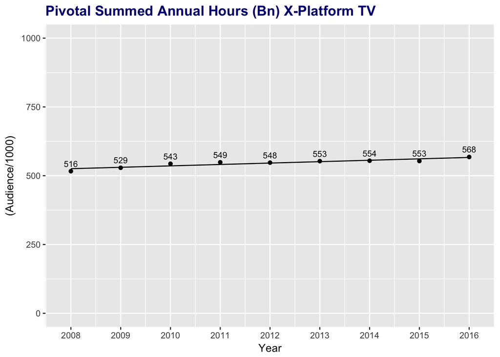

```
##    Min. 1st Qu.  Median    Mean 3rd Qu.    Max.
##  516400  543500  548900  546000  553400  568100
```

```
##
## Call:
## lm(formula = log(Audience) ~ Year, data = Nielsen_videodf)
##
## Residuals:
##       Min        1Q    Median        3Q       Max
## -0.017751 -0.003316  0.002310  0.003613  0.014994
##
## Coefficients:
##              Estimate Std. Error t value Pr(>|t|)
## (Intercept) -5.766879   3.120450  -1.848   0.1071
## Year         0.009432   0.001551   6.081   0.0005 ***
## ---
## Signif. codes:  0 '***' 0.001 '**' 0.01 '*' 0.05 '.' 0.1 ' ' 1
##
## Residual standard error: 0.01201 on 7 degrees of freedom
## Multiple R-squared:  0.8409, Adjusted R-squared:  0.8181
## F-statistic: 36.98 on 1 and 7 DF,  p-value: 0.0005001
```

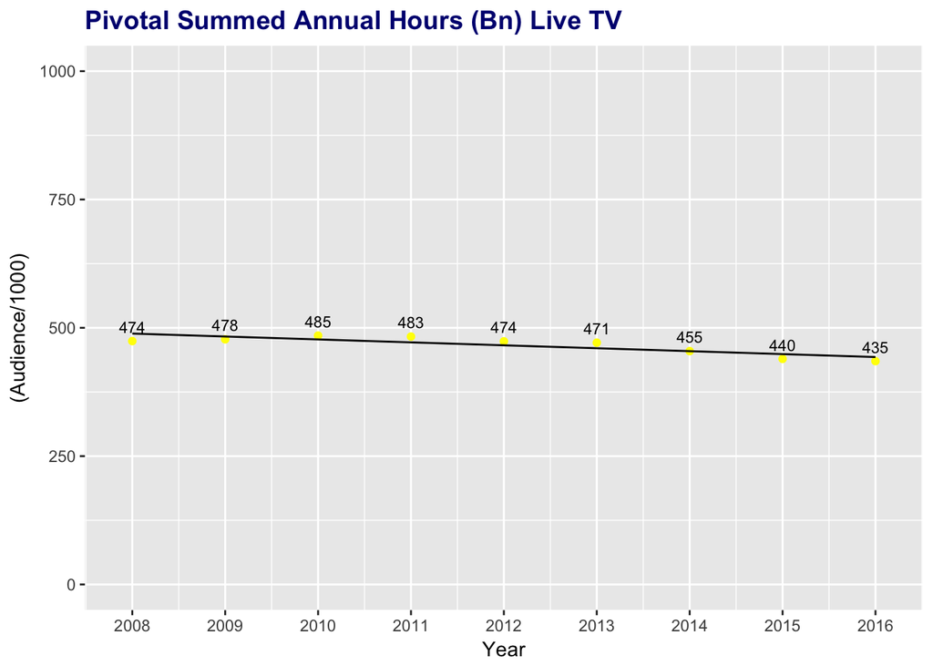

Pivotal research’s total hours viewed estimate for Live TV viewing is 465,900 spanning 2008-2016.

The log-transformed regression model, enables percentage based reporting and shows a -1% decrease per year in audience on average, at a 99% confidence interval.

```
##    Min. 1st Qu.  Median    Mean 3rd Qu.    Max.
##  435100  454600  473600  465900  477600  484900
```

```
##
## Call:
## lm(formula = log(Audience) ~ Year, data = Nielsen_Livedf)
##
## Residuals:
##       Min        1Q    Median        3Q       Max
## -0.031577 -0.017966  0.001029  0.017083  0.024079
##
## Coefficients:
##              Estimate Std. Error t value Pr(>|t|)
## (Intercept) 38.090446   5.870107   6.489 0.000338 ***
## Year        -0.012445   0.002918  -4.266 0.003721 **
## ---
## Signif. codes:  0 '***' 0.001 '**' 0.01 '*' 0.05 '.' 0.1 ' ' 1
##
## Residual standard error: 0.0226 on 7 degrees of freedom
## Multiple R-squared:  0.7222, Adjusted R-squared:  0.6825
## F-statistic:  18.2 on 1 and 7 DF,  p-value: 0.003721
```

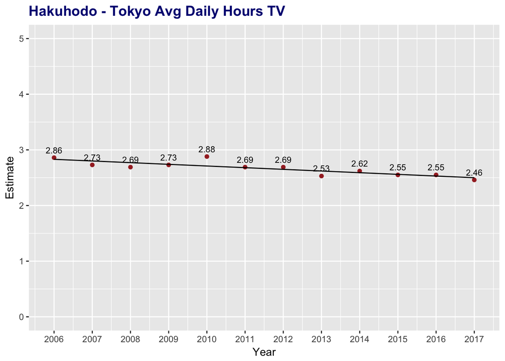

According to the Hakuhodo survey, respondents report watching live TV, for 2.67 hours per day.

See regression output below:

```
##    Min. 1st Qu.  Median    Mean 3rd Qu.    Max.
##   2.460   2.550   2.690   2.665   2.730   2.880
```

```
##
## Call:
## lm(formula = Estimate ~ Year, data = Tokyo_videodf)
##
## Residuals:
##       Min        1Q    Median        3Q       Max
## -0.089895 -0.047290  0.000105  0.029755  0.169895
##
## Coefficients:
##              Estimate Std. Error t value Pr(>|t|)
## (Intercept) 63.150664  12.360804   5.109 0.000458 ***
## Year        -0.030070   0.006145  -4.893 0.000629 ***
## ---
## Signif. codes:  0 '***' 0.001 '**' 0.01 '*' 0.05 '.' 0.1 ' ' 1
##
## Residual standard error: 0.07348 on 10 degrees of freedom
## Multiple R-squared:  0.7054, Adjusted R-squared:  0.6759
## F-statistic: 23.94 on 1 and 10 DF,  p-value: 0.0006293
```

## CORRELATION ANALYSIS

Essentially we’ve analyzed data from a variety of sources, that leverage different methodologies - but all indicating that Live TV viewing is decreasing while cross-platform TV is increasing. In this section we’ll examine the correlation between these different data sources for further confirmation of the trends we’ve observed.

For example, Hakuhodo Tokyo survey research and Nielsen Live TV ratings have a Pearson’s R value of .74 - indicating a very strong positive correlation between the two sources. The data sets represent different methodologies, that are attempting to measure the same phenomenon - and both are indicating that live TV viewing is declining. The fact that they have strong correlation, serves evidence that the live TV - regardless of how it’s measured is declining.

Additionally, we can see for the correlation stats below, when comparing ATUS computer usage to its own survey data for cross-platform TV usage (.72), and Pivotal Research cross-platform TV viewing estimates (.58) that there is positive correlation. In other words, computer/online usage doesn’t seem to negatively impact cross-platform video viewing.

However, when we correlate ATUS cross-platform TV viewing data with Nielsen/Pivotal cross-platform estimates we actually see a negative correlation (-.23). How is that possible? From 2003-2016, the ATUS cross-platform averages a positive growth rate, but from 2008-2016 (the years that we have Pivotal Research estimates), the trend is actually flat. In other words, from 2008-2016 the ATUS survey data for cross-platform viewing trends virtually flat but statically insignificant (.00, p = .81)[^7], while the Nielsen/Pivotal research data trends positive - explaining the divergence between the two data sets.

In the final analysis, it’s been found to be statistically significant from multiple sources (albeit in different markets), that live TV viewing is decreasing.

However, regarding overall cross-platform video viewing the picture becomes a little murky with the narrative ranging from flat to slight growth depending on the years in question.

Finally, non-video computer/mobile use positively correlates with overall video viewing, and therefore doesn’t negatively impact cross-platform viewing of TV programming.

|  | Pearson’s R |
| --- | --- |
| ATUS Computer & TV Correlation | 0.7257461 |
| Hakuhodo & Pivotal Live TV Correlation | 0.7365505 |
| ATUS TV & Pivotal Xplatform Correlation | -0.2376375 |
| ATUS Computer & Pivotal Xplatform Correlation | 0.5829963 |

## FIVE-YEAR FORECAST & SUMMARY

### ATUS COMPUTER USAGE FORECAST

```
## Initial log joint probability = -2.17335
## Optimization terminated normally:
##   Convergence detected: absolute parameter change was below tolerance
```

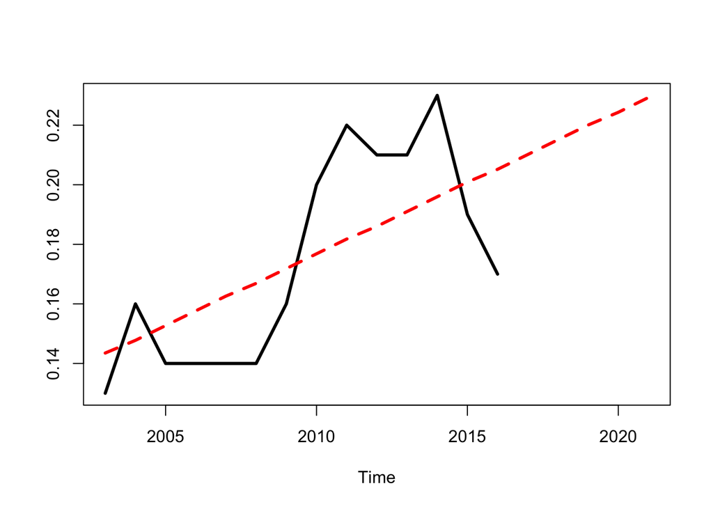

```
## [1] 0.2101460 0.2151045 0.2200539 0.2243232 0.2292907
```

|  | future prediction |
| --- | --- |
| 2017 | 0.21 |
| 2018 | 0.22 |
| 2019 | 0.22 |
| 2020 | 0.22 |
| 2021 | 0.23 |

|  | upper | mean | lower |
| --- | --- | --- | --- |
| Actual | 0.1943782 | 0.1742857 | 0.1541932 |
| Prediction | 0.2098049 | 0.1982375 | 0.1866701 |

### ATUS CROSS-PLATFORM TV VIEWING FORECAST

```
## Initial log joint probability = -2.02331
## Optimization terminated normally:
##   Convergence detected: absolute parameter change was below tolerance
```

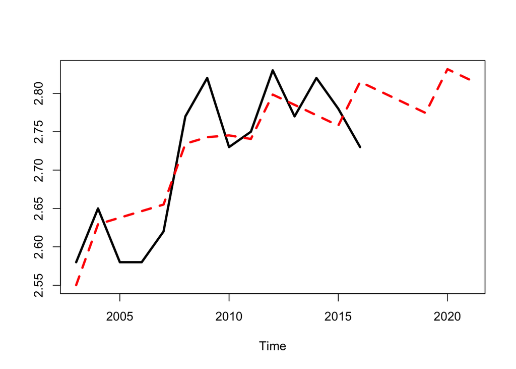

```
## [1] 2.801507 2.787966 2.774422 2.831515 2.817998
```

|  | future prediction |
| --- | --- |
| 2017 | 2.80 |
| 2018 | 2.79 |
| 2019 | 2.77 |
| 2020 | 2.83 |
| 2021 | 2.82 |

|  | upper | mean | lower |
| --- | --- | --- | --- |
| Actual | 2.769341 | 2.715000 | 2.660659 |
| Prediction | 2.797143 | 2.778878 | 2.760613 |

### PIVOTAL CROSS-PLATFORM TV VIEWING FORECAST

```
## Initial log joint probability = -2.0175
## Optimization terminated normally:
##   Convergence detected: absolute parameter change was below tolerance
```

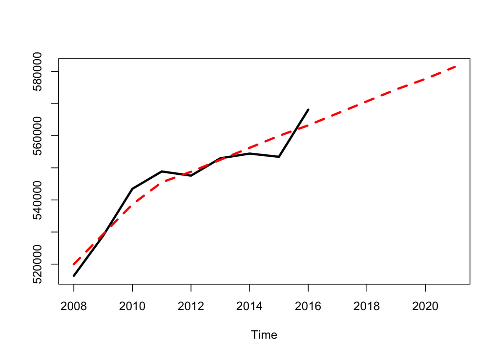

|  | future prediction |
| --- | --- |
| 2017 | 566,977 |
| 2018 | 570,706 |
| 2019 | 574,426 |
| 2020 | 577,705 |
| 2021 | 581,442 |

|  | upper | mean | lower |
| --- | --- | --- | --- |
| Actual | 557711.9 | 546008.6 | 534305.2 |
| Prediction | 566661.3 | 556098.1 | 545534.9 |

### Forecast summary table below:

|  | ATUS Online Time | ATUS All-TV Time | Pivotal Total Hours (Bn) |
| --- | --- | --- | --- |
| 2017 | 0.21 | 2.80 | 567 |
| 2018 | 0.22 | 2.79 | 571 |
| 2019 | 0.22 | 2.77 | 574 |
| 2020 | 0.22 | 2.83 | 578 |
| 2021 | 0.23 | 2.82 | 581 |

### ANALYSIS & FINDINGS

The primary goals of our analysis, was to answer two questions:

- Has overall video usage been increasing or decreasing
- Will people be spending more time with non-video activity at the expense of video usage.

The problem in answering the first question is that there’s no single source of truth. Therefore, we broke our analysis into two parts - first to determine what our sources were predicting for video usage, by type (Live TV vs Cross-Platform). Once we established which sources were aimed at measuring the same phenomena, albeit with different methods, the next step was to determine if they correlated together - essentially telling the same story.

As we saw in our correlation section, generally this was the case. Finally, once we determined with some statistical confidence that trends were either decreasing or increasing, the next step was to try and provide five-year forecasts for our key behaviors of interest - overall computer usage (excl. games), ATUS reporting all TV viewing and Pivotal Research estimated Cross-platform TV viewing.

The ATUS survey based date reported computer usage and cross-platform TV usage trending up, but predicted means were more than one standard deviation from the observed means, limiting our confidence in the exact predictions - but not the direction. However, our predicted values from Pivotal research for total annual hours of cross-platform viewing was within one standard deviation of the actual or observed values, confirming the validity of those predicted values. Fundamentally, the variability in the data reflects the disruption in the marketplace that makes it virtually impossible to predict what will happen in the next 3-5 years. However, when trying to determine which direction usage is headed, up or down, the projections are useful in providing credible insight.

In sum, all sources point to continuing declines in live TV viewing, but continued growth when looking at cross-platform growth. It’s also worth noting that the growth of cross-platform TV viewing is not negatively correlated with non-video online activity.

## APPENDIX - DATA DISTRIBUTION

```
##    Min. 1st Qu.  Median    Mean 3rd Qu.    Max.
##  0.1300  0.1400  0.1650  0.1743  0.2075  0.2300
```

```
##    Min. 1st Qu.  Median    Mean 3rd Qu.    Max.
##   2.580   2.628   2.740   2.715   2.778   2.830
```

```
##    Min. 1st Qu.  Median    Mean 3rd Qu.    Max.
##   2.350   2.443   2.535   2.506   2.570   2.610
```

```
##    Min. 1st Qu.  Median    Mean 3rd Qu.    Max.
##  516400  543500  548900  546000  553400  568100
```

```
##    Min. 1st Qu.  Median    Mean 3rd Qu.    Max.
##  435100  454600  473600  465900  477600  484900
```

```
##    Min. 1st Qu.  Median    Mean 3rd Qu.    Max.
##   2.460   2.550   2.690   2.665   2.730   2.880
```

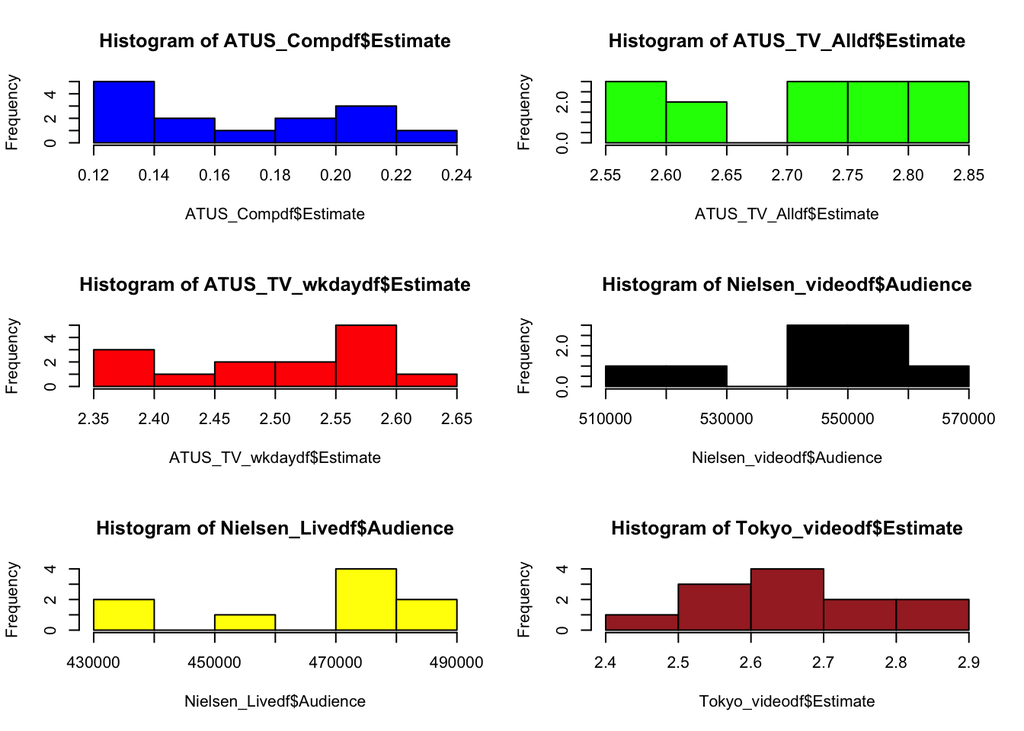

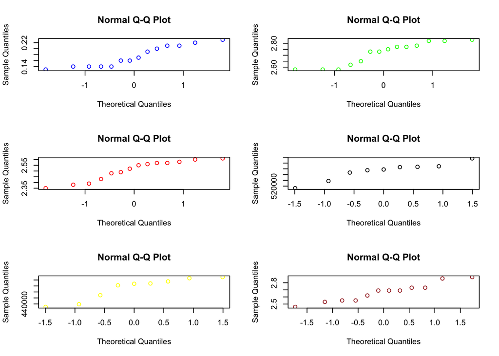

## DATA SOURCES & FOOTNOTES

```
##
## Call:
## lm(formula = Estimate[6:14] ~ Year[6:14], data = ATUS_TV_Alldf)
##
## Residuals:
##       Min        1Q    Median        3Q       Max
## -0.050444 -0.029111 -0.006444  0.038222  0.052222
##
## Coefficients:
##              Estimate Std. Error t value Pr(>|t|)
## (Intercept)  5.460444  10.596097   0.515    0.622
## Year[6:14]  -0.001333   0.005266  -0.253    0.807
##
## Residual standard error: 0.04079 on 7 degrees of freedom
## Multiple R-squared:  0.009074,   Adjusted R-squared:  -0.1325
## F-statistic: 0.0641 on 1 and 7 DF,  p-value: 0.8074
```

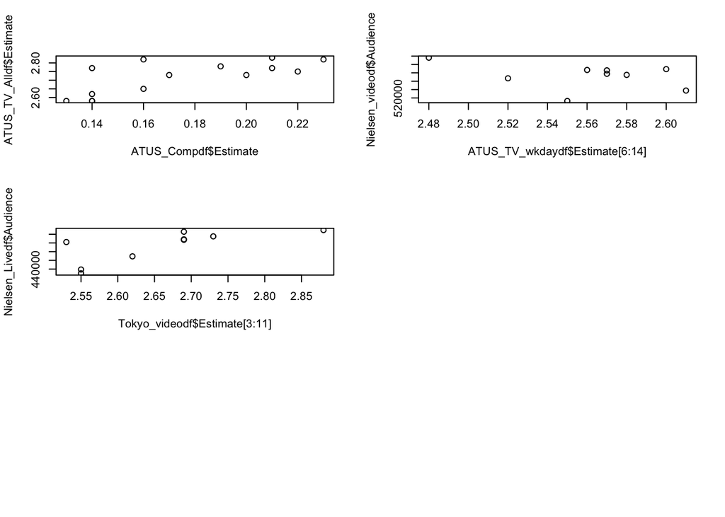

[^1]: [You can watch Netflix on any screen you want, but you’re probably watching it on a TV](https://www.recode.net/2018/3/7/17094610/netflix-70-percent-tv-viewing-statistics)
[^2]: [Hulu Japan Launches, But Falls Flat](https://ishikawajet.wordpress.com/2011/09/02/hulu-japan-launches-but-falls-flat/)
[^3]: [Netflix Japan vs Hulu Japan: Which one is the best?](https://www.kuropixel.com/netflix-japan-vs-hulu-japan/)
[^4]: [Series ID: TUU10101AA01006114  
    Type of estimate: Average hours per day  
    Activity: Computer use for leisure Day of week: All days  
    Age: 15 years and over ]
[^5]: [Series ID: TUU10101AA01014236  
    Type of estimate: Average hours per day  
    Activity: Watching TV Day of week: All days  
    Age: 15 years and over]
[^6]: [Series ID: TUU10101AA01014241  
    Type of estimate: Average hours per day  
    Activity: Watching TV  
    Day of week: Nonholiday weekdays  
    Age: 15 years and over]
[^7]: [ATUS TV Viewing from 2008-2016]